# AdvanceMLPreparation

Ritesh Kumar

7/4/2017

```r
rm(list=ls())
```

## Load libraries

```r
library(rdatamarket)
library(forecast)
library(tseries)
```

## usefull timeseries functions

```r
data()
# print(EuStockMarkets)

#View the Data
data <-dmlist("http://data.is/1RvZGQL")
class(data)
```

```
## [1] "data.frame"
```

```r
# Is this data a time series Object ?
is.ts(data)
```

```
## [1] FALSE
```

```r
# Get Time Series Data
tsdata<-as.ts(dmseries("http://data.is/1RvZGQL"))

# Is this data a time series Object ?
is.ts(tsdata)
```

```
## [1] TRUE
```

```r
# Time Series Object
# print(ts(tsdata))
# Time Series first 10 observations
head(tsdata, 10)
```

```
##      Jan Feb Mar Apr May Jun Jul Aug Sep Oct
## 1963 501 488 504 578 545 632 728 725 585 542
```

```r
# Time Series last 10 observations
tail(tsdata, 10)
```

```
##       Mar  Apr  May  Jun  Jul  Aug  Sep  Oct  Nov  Dec
## 1976  745  844  833  935 1110 1124  868  860  762  877
```

```r
# Time Series number of observations
length(tsdata)
```

```
## [1] 168
```

```r
# Time Series start of observations
start(tsdata)
```

```
## [1] 1963    1
```

```r
# Time Series start of observations
end(tsdata)
```

```
## [1] 1976   12
```

```r
# Vector of times at which a time series was sampled
time(tsdata)
```

```
##           Jan      Feb      Mar      Apr      May      Jun      Jul
## 1963 1963.000 1963.083 1963.167 1963.250 1963.333 1963.417 1963.500
## 1964 1964.000 1964.083 1964.167 1964.250 1964.333 1964.417 1964.500
## 1965 1965.000 1965.083 1965.167 1965.250 1965.333 1965.417 1965.500
## 1966 1966.000 1966.083 1966.167 1966.250 1966.333 1966.417 1966.500
## 1967 1967.000 1967.083 1967.167 1967.250 1967.333 1967.417 1967.500
## 1968 1968.000 1968.083 1968.167 1968.250 1968.333 1968.417 1968.500
## 1969 1969.000 1969.083 1969.167 1969.250 1969.333 1969.417 1969.500
## 1970 1970.000 1970.083 1970.167 1970.250 1970.333 1970.417 1970.500
## 1971 1971.000 1971.083 1971.167 1971.250 1971.333 1971.417 1971.500
## 1972 1972.000 1972.083 1972.167 1972.250 1972.333 1972.417 1972.500
## 1973 1973.000 1973.083 1973.167 1973.250 1973.333 1973.417 1973.500
## 1974 1974.000 1974.083 1974.167 1974.250 1974.333 1974.417 1974.500
## 1975 1975.000 1975.083 1975.167 1975.250 1975.333 1975.417 1975.500
## 1976 1976.000 1976.083 1976.167 1976.250 1976.333 1976.417 1976.500
##           Aug      Sep      Oct      Nov      Dec
## 1963 1963.583 1963.667 1963.750 1963.833 1963.917
## 1964 1964.583 1964.667 1964.750 1964.833 1964.917
## 1965 1965.583 1965.667 1965.750 1965.833 1965.917
## 1966 1966.583 1966.667 1966.750 1966.833 1966.917
## 1967 1967.583 1967.667 1967.750 1967.833 1967.917
## 1968 1968.583 1968.667 1968.750 1968.833 1968.917
## 1969 1969.583 1969.667 1969.750 1969.833 1969.917
## 1970 1970.583 1970.667 1970.750 1970.833 1970.917
## 1971 1971.583 1971.667 1971.750 1971.833 1971.917
## 1972 1972.583 1972.667 1972.750 1972.833 1972.917
## 1973 1973.583 1973.667 1973.750 1973.833 1973.917
## 1974 1974.583 1974.667 1974.750 1974.833 1974.917
## 1975 1975.583 1975.667 1975.750 1975.833 1975.917
## 1976 1976.583 1976.667 1976.750 1976.833 1976.917
```

```r
# Return the time interval between observations
deltat(tsdata)
```

```
## [1] 0.08333333
```

```r
# Return the number of samples per unit time
frequency(tsdata)
```

```
## [1] 12
```

```r
# Return the positions in the cycle of each observation
cycle(tsdata)
```

```
##      Jan Feb Mar Apr May Jun Jul Aug Sep Oct Nov Dec
## 1963   1   2   3   4   5   6   7   8   9  10  11  12
## 1964   1   2   3   4   5   6   7   8   9  10  11  12
## 1965   1   2   3   4   5   6   7   8   9  10  11  12
## 1966   1   2   3   4   5   6   7   8   9  10  11  12
## 1967   1   2   3   4   5   6   7   8   9  10  11  12
## 1968   1   2   3   4   5   6   7   8   9  10  11  12
## 1969   1   2   3   4   5   6   7   8   9  10  11  12
## 1970   1   2   3   4   5   6   7   8   9  10  11  12
## 1971   1   2   3   4   5   6   7   8   9  10  11  12
## 1972   1   2   3   4   5   6   7   8   9  10  11  12
## 1973   1   2   3   4   5   6   7   8   9  10  11  12
## 1974   1   2   3   4   5   6   7   8   9  10  11  12
## 1975   1   2   3   4   5   6   7   8   9  10  11  12
## 1976   1   2   3   4   5   6   7   8   9  10  11  12
```

```r
# Caculatethe sample mean
mean(tsdata)
```

```
## [1] 722.2976
```

```r
# Get the value distribution of the observations.
summary(tsdata)
```

```
##  Monthly.hotel.occupied.room.av...63..76.B.L.Bowerman.et.al
##  Min.   : 480.0
##  1st Qu.: 613.5
##  Median : 709.5
##  Mean   : 722.3
##  3rd Qu.: 803.8
##  Max.   :1125.0
```

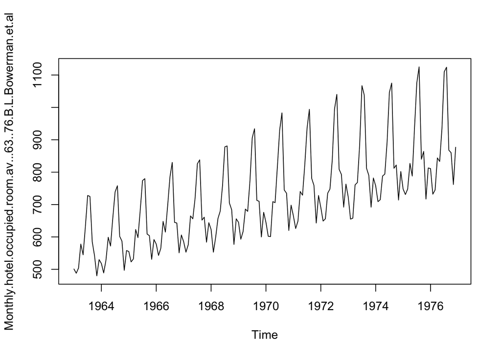

```r
# Visualize the Time Series
plot(tsdata)
```

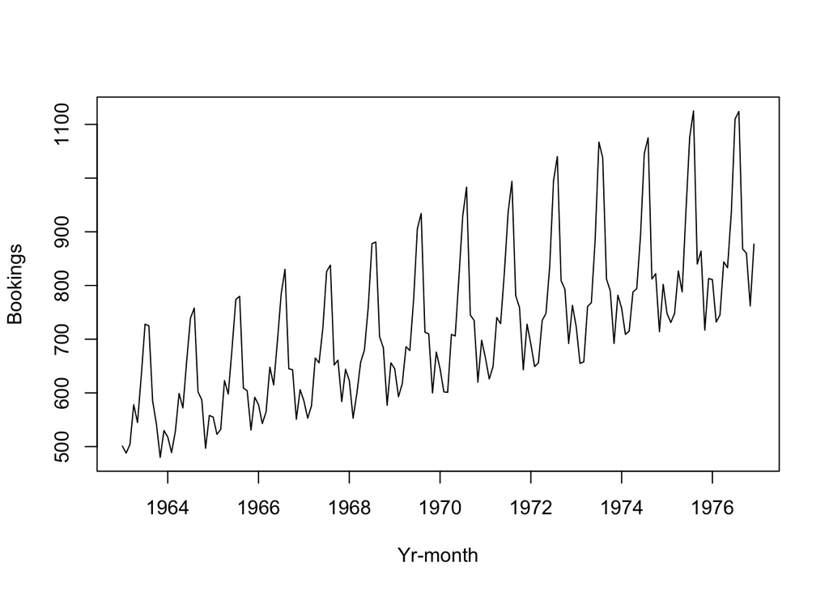

```r
# Visualize and edit the Time Series Axis names
plot(tsdata, xlab= "Yr-month", ylab= "Bookings")
```

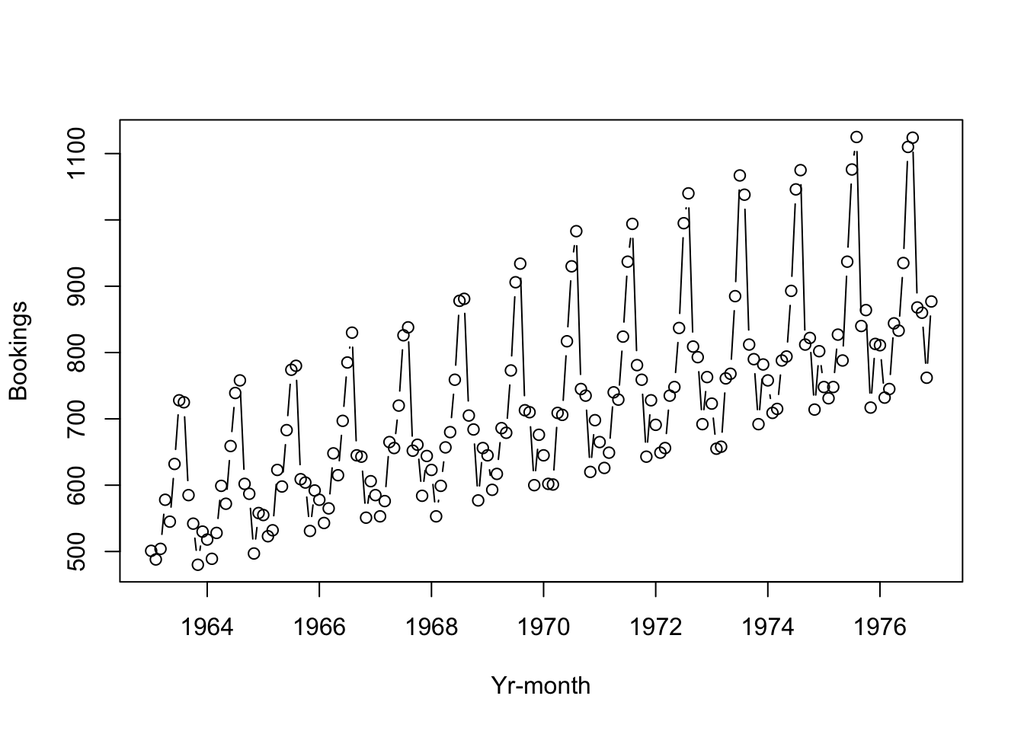

```r
# # Visualize and edit the Time Series plotting type (Default type in "l")
plot(tsdata, xlab= "Yr-month", ylab= "Bookings", type = "b")
```

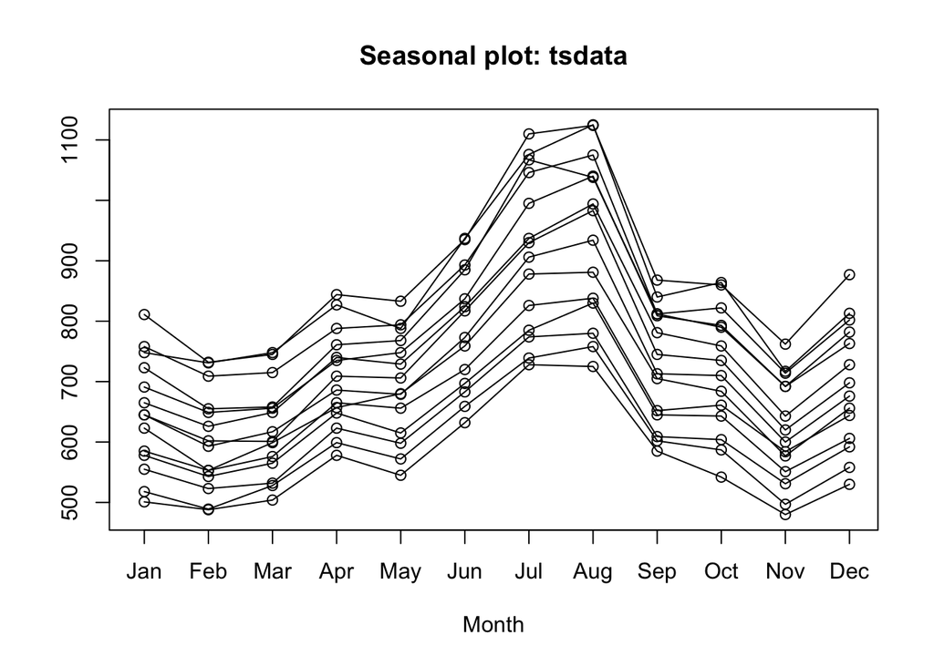

```r
# Visualize seasonal plot
seasonplot(tsdata)
```

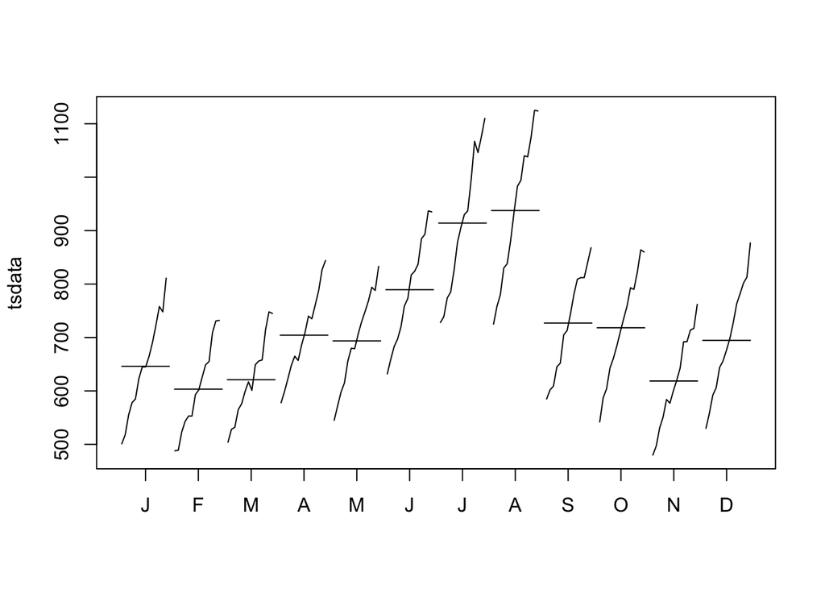

```r
# Visualize seasonal sub-series plot or month plot.
monthplot(tsdata)
```

## White noise

```r
# Simulating white Noise Model
WN_1 <-arima.sim(model = list(order= c(0,0,0)), n=50)
head(WN_1)
```

```
## Time Series:
## Start = 1
## End = 6
## Frequency = 1
## [1]  0.78465410 -0.23384252 -0.81195111  0.08211593 -0.54319488 -0.80756011
```

```r
head(WN_1, 10)
```

```
## Time Series:
## Start = 1
## End = 10
## Frequency = 1
##  [1]  0.78465410 -0.23384252 -0.81195111  0.08211593 -0.54319488
##  [6] -0.80756011  1.00470721  0.26678444 -0.03014906 -1.13566856
```

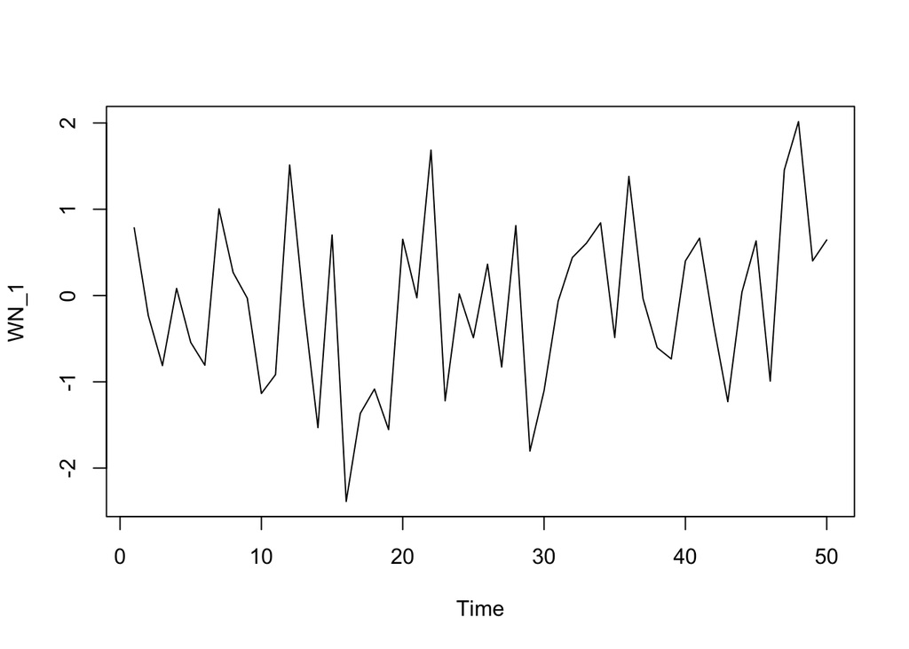

```r
ts.plot(WN_1)
```

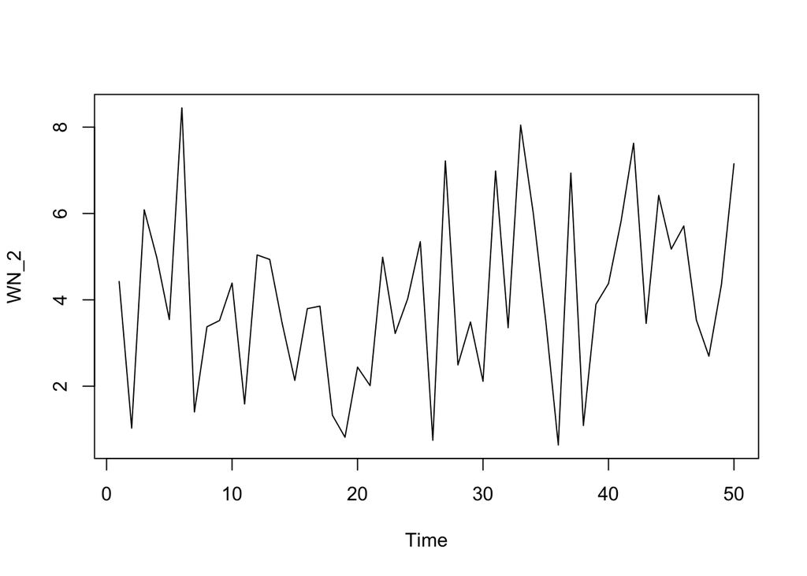

```r
# Simulating white Noise Model with mean and SD
WN_2 <-arima.sim(model = list(order= c(0,0,0)), n=50, mean=4, sd=2)
ts.plot(WN_2)
```

```r
# Extimatingwhite Noise Model
arima(WN_2,order = c(0,0,0))
```

```
##
## Call:
## arima(x = WN_2, order = c(0, 0, 0))
##
## Coefficients:
##       intercept
##          4.0599
## s.e.     0.2861
##
## sigma^2 estimated as 4.094:  log likelihood = -106.18,  aic = 216.37
```

```r
#Alternatively
mean(WN_2)
```

```
## [1] 4.059853
```

```r
var(WN_2)
```

```
## [1] 4.177399
```

## Random Walk

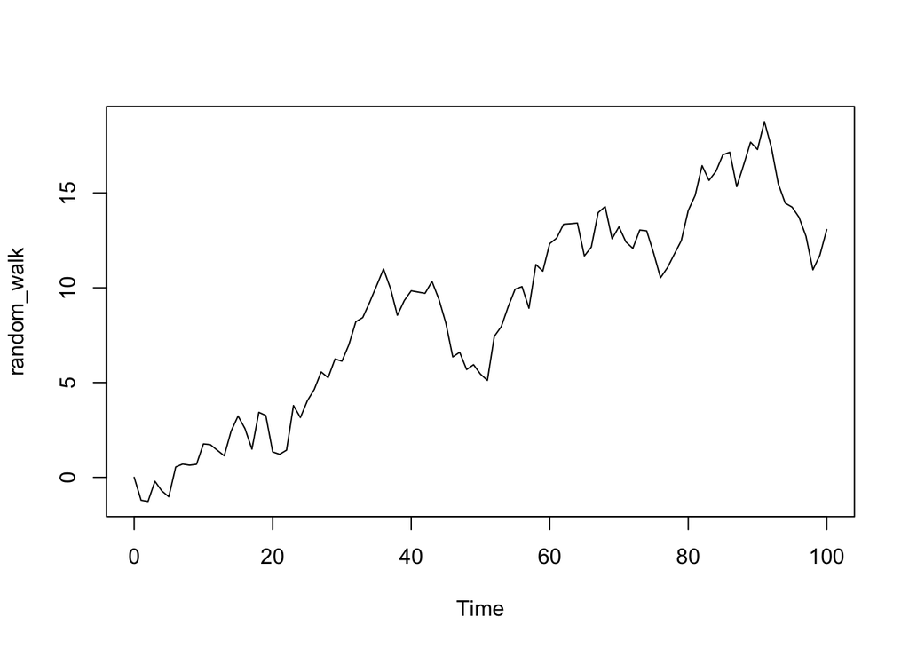

```r
# Generate a RW model using arima.sim
random_walk<-arima.sim(model = list(order = c(0, 1, 0)), n = 100)
# Plot random_walk
ts.plot(random_walk)
```

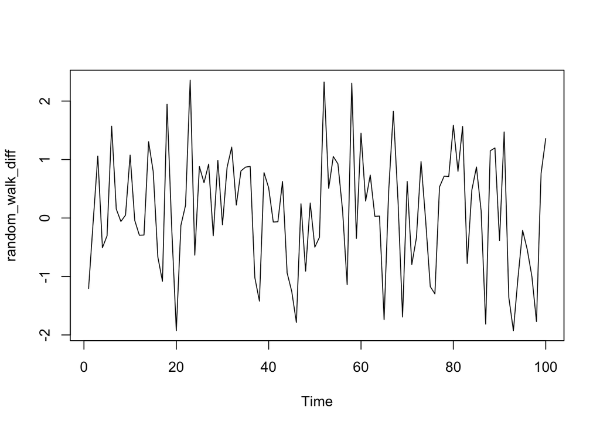

```r
# Calculate the first difference series
random_walk_diff<-diff(random_walk)
# Plot random_walk_diff
ts.plot(random_walk_diff)
```

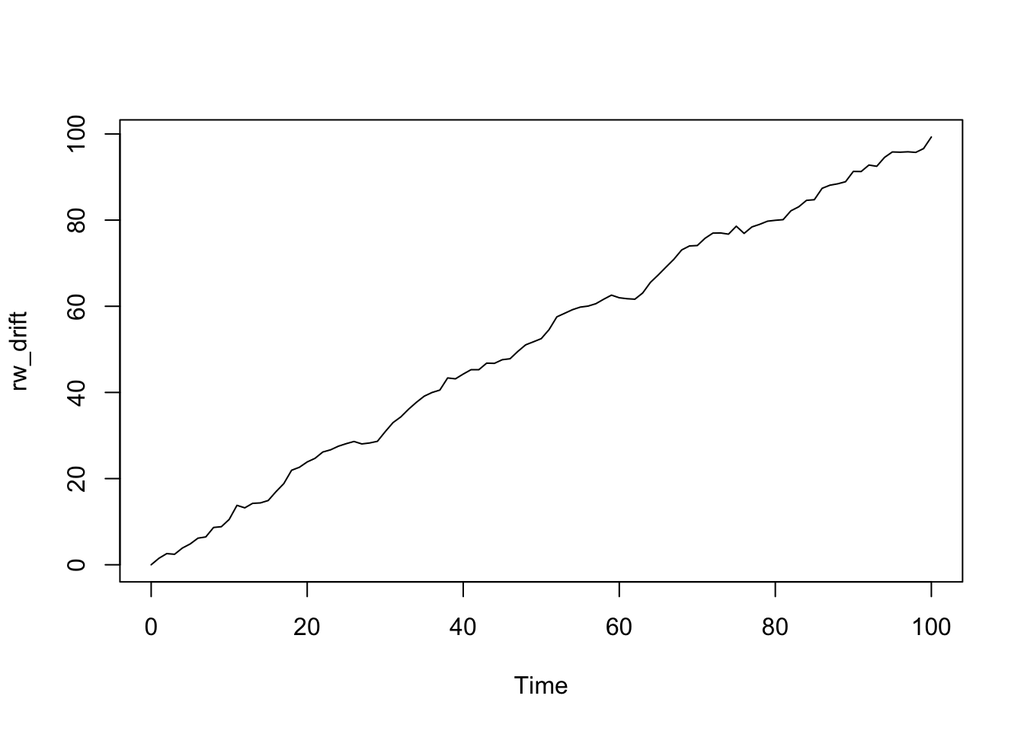

```r
# Generate a RW model with a drift uingarima.sim
rw_drift<-arima.sim(model = list(order = c(0, 1, 0)), n = 100, mean=1)

# Plot rw_drift
ts.plot(rw_drift)
```

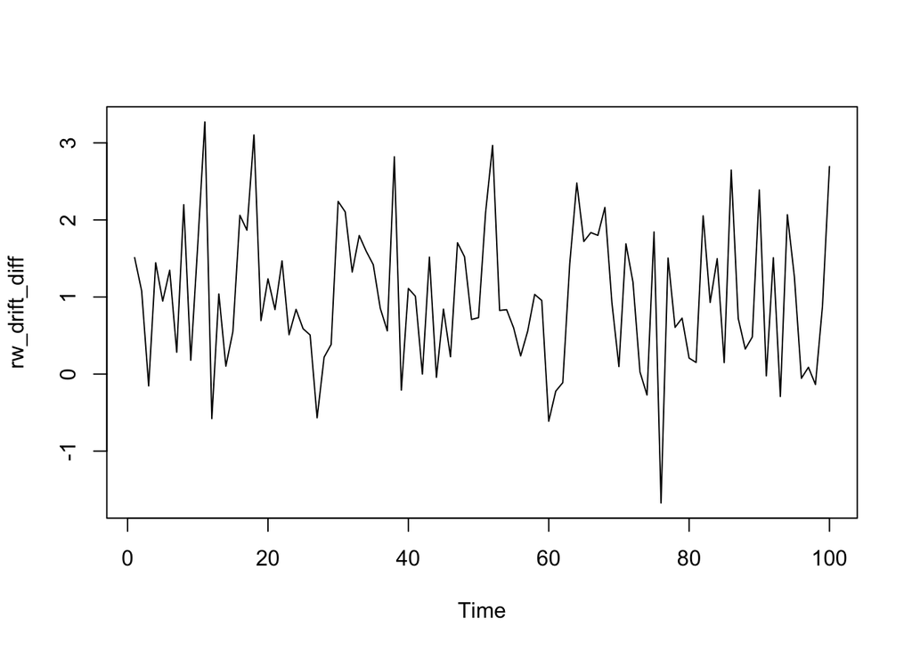

```r
# Calculate the first difference series
rw_drift_diff<-diff(rw_drift)
# Plot rw_drift_diff
ts.plot(rw_drift_diff)
```

```r
# Fit WN model to diff series
rwmodel<-arima(rw_drift_diff,order= c(0,0,0))
# View model
rwmodel$sigma2
```

```
## [1] 0.8577806
```

## Covariance and corelation

```r
#Covariance
cov(1:10,11:20)
```

```
## [1] 9.166667
```

```r
#Correlation
cor(1:10,11:20)
```

```
## [1] 1
```

```r
#Correlation
cov(1:10,11:20)/sd(1:10)*sd(11:20)
```

```
## [1] 9.166667
```

### Introduction to ARMA Time Series Modeling

#### AR - Auto Regression - x(t) = alpha * x(t – 1) + error (t) - Any shock to x(t) will gradually fade off in future.

#### MA - Moving Average - x(t) = beta * error(t-1) + error (t) - Any noise / shock quickly vanishes with time

#### AR or MA are not applicable on non-stationary series.

### Exploiting ACF and PACF plots

#### Once we have got the stationary time series, we must answer two primary questions:

#### Q1. Is it an AR or MA process?

#### Q2. What order of AR or MA process do we need to use?

##### The first question can be answered using Total Correlation Chart (also known as Auto – correlation Function / ACF). ACF is a plot of total correlation between different lag functions.In a moving average series of lag n, we will not get any correlation between x(t) and x(t – n -1). Hence, the total correlation chart cuts off at nth lag. So it becomes simple to find the lag for a MA series.

##### For an AR series this correlation will gradually go down without any cut off value. Here is the second trick. If we find out the partial correlation of each lag, it will cut off after the degree of AR series. For instance,if we have a AR(1) series, if we exclude the effect of 1st lag (x (t-1) ), our 2nd lag (x (t-2) ) is independent of x(t). Hence, the partial correlation function (PACF) will drop sharply after the 1st lag.

## Step 1: Visualize the Time Series

### Exploration of Time Series Data in R

```r
# Loading the Data Set
data(AirPassengers)
class(AirPassengers)
```

```
## [1] "ts"
```

```r
start(AirPassengers)
```

```
## [1] 1949    1
```

```r
end(AirPassengers)
```

```
## [1] 1960   12
```

```r
frequency(AirPassengers)
```

```
## [1] 12
```

```r
cycle(AirPassengers)
```

```
##      Jan Feb Mar Apr May Jun Jul Aug Sep Oct Nov Dec
## 1949   1   2   3   4   5   6   7   8   9  10  11  12
## 1950   1   2   3   4   5   6   7   8   9  10  11  12
## 1951   1   2   3   4   5   6   7   8   9  10  11  12
## 1952   1   2   3   4   5   6   7   8   9  10  11  12
## 1953   1   2   3   4   5   6   7   8   9  10  11  12
## 1954   1   2   3   4   5   6   7   8   9  10  11  12
## 1955   1   2   3   4   5   6   7   8   9  10  11  12
## 1956   1   2   3   4   5   6   7   8   9  10  11  12
## 1957   1   2   3   4   5   6   7   8   9  10  11  12
## 1958   1   2   3   4   5   6   7   8   9  10  11  12
## 1959   1   2   3   4   5   6   7   8   9  10  11  12
## 1960   1   2   3   4   5   6   7   8   9  10  11  12
```

```r
summary(AirPassengers)
```

```
##    Min. 1st Qu.  Median    Mean 3rd Qu.    Max.
##   104.0   180.0   265.5   280.3   360.5   622.0
```

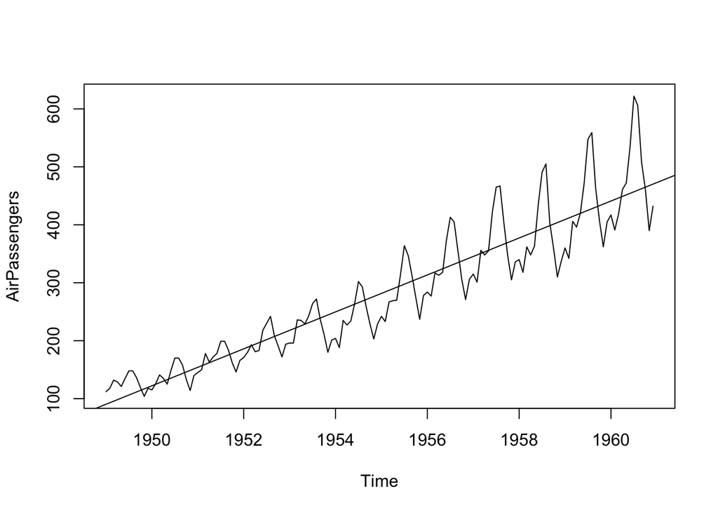

```
## integer(0)
```

```r
plot(AirPassengers) +
abline(reg=lm(AirPassengers~time(AirPassengers)))
```

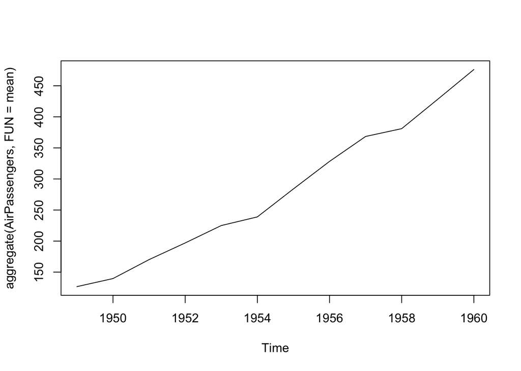

```r
#This will aggregate the cycles and display a year on year trend
plot(aggregate(AirPassengers,FUN=mean))
```

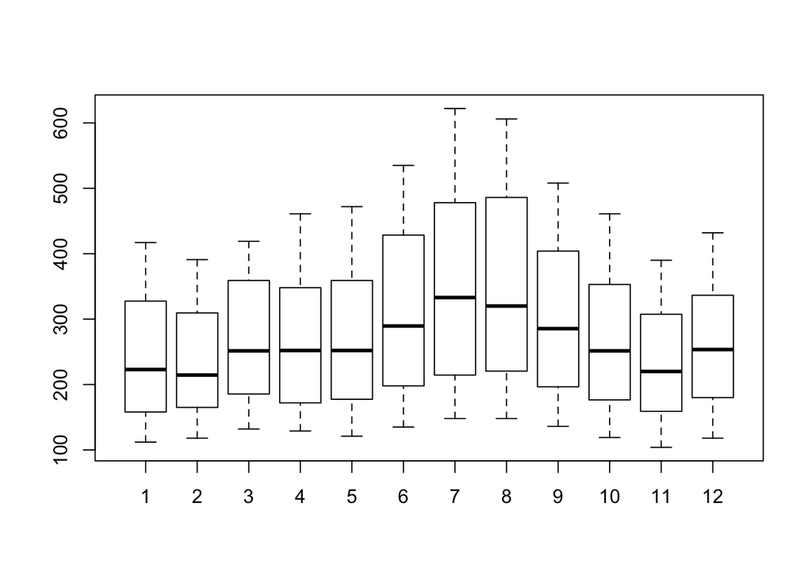

```r
#Box plot across months will give us a sense on seasonal effect
boxplot(AirPassengers~cycle(AirPassengers))
```

```r
## Conclusion:
#   The year on year trend clearly shows that the #passengers have been increasing without fail.
#   The variance and the mean value in July and August is much higher than rest of the months.
#   Even though the mean value of each month is quite different their variance is small. Hence,
#   we have strong seasonal effect with a cycle of 12 months or less.
```

## Step 2: Stationarize the Series

### Once we know the patterns, trends, cycles and seasonality , we can check if the series is stationary or not. Dickey – Fuller is one of the popular test to check the same.If the null hypothesis gets rejected, we’ll get a stationary time series.

### What if the series is found to be non-stationary?

#### There are three commonly used technique to make a time series stationary:

#### 1. Detrending - simply remove the trend component from the time series

#### 2. Differencing : This is the commonly used technique to remove non-stationarity.Here we try to model the differences of the terms and not the actual term. This differencing is called as the Integration part in AR(I)MA. i.e x(t) – x(t-1) = ARMA (p , q) .The number of times of differencing needed to render the series stationary will be the differenced I(d) term in our ARIMA model.

#### Now, we have three parameters

##### p : AR

##### d : I

##### q : MA

#### 3. Seasonality : Seasonality can easily be incorporated in the ARIMA model directly.

```r
adf.test(diff(log(AirPassengers)), alternative="stationary", k=0)
```

```
##
##  Augmented Dickey-Fuller Test
##
## data:  diff(log(AirPassengers))
## Dickey-Fuller = -9.6003, Lag order = 0, p-value = 0.01
## alternative hypothesis: stationary
```

```r
# We see that the series is stationary enough to do any kind of time series modelling.
```

## Step 3: Find Optimal Parameters

#### The parameters p,d,q can be found using ACF and PACF plots.An addition to this approach is can be, if both ACF and PACF decreases gradually, it indicates that we need to make the time series stationary and introduce a value to “d”.

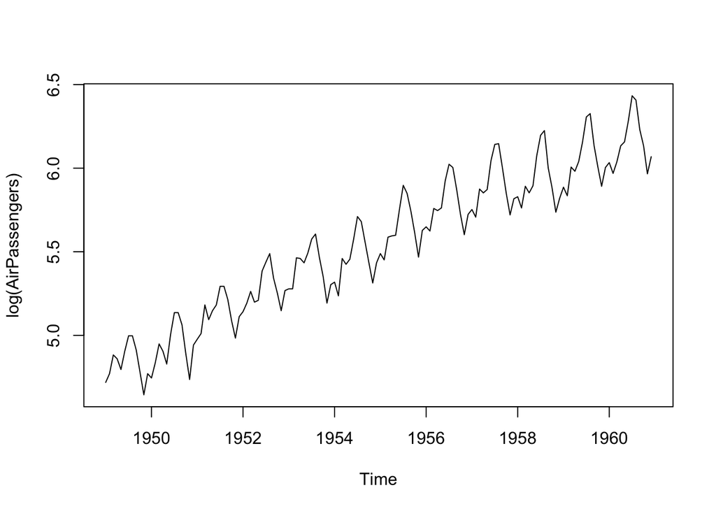

```r
#ACF Plots
plot(log(AirPassengers))
```

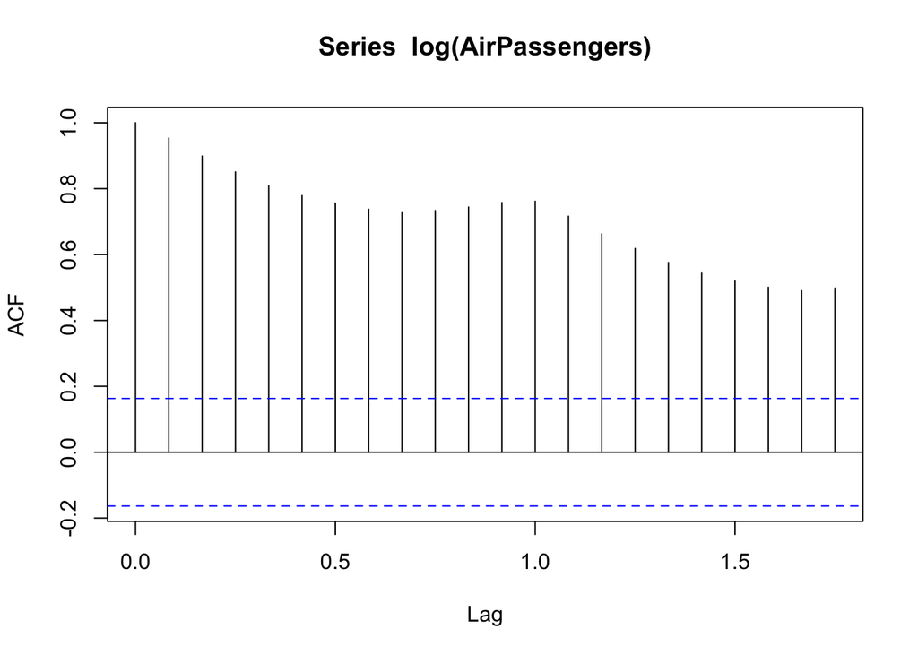

```r
acf(log(AirPassengers))
```